# analysis_for_veam

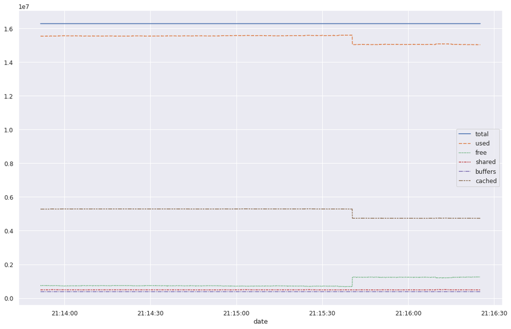

```python
plt.figure(figsize=(16,10), dpi= 80)
sns.set(style='darkgrid')
sns.lineplot(data=mem_df)
```

```python
dsk_df = dsk_df.set_index(dsk_df.date).drop(columns=['date'])
dsk_df.head(2)
```

| date | tps | kB_read_s | kB_wrtn_s | kB_read | kB_wrtn |
| --- | --- | --- | --- | --- | --- |
| 2020-05-12 21:13:51.665 | 13.86 | 402.3 | 786.97 | 231112041 | 452094992 |
| 2020-05-12 21:13:52.673 | 13.86 | 402.3 | 786.97 | 231112177 | 452095096 |

```python
dsk_df.info()
```

```
<class 'pandas.core.frame.DataFrame'>
DatetimeIndex: 153 entries, 2020-05-12 21:13:51.665000 to 2020-05-12 21:16:24.901000
Data columns (total 5 columns):
 #   Column     Non-Null Count  Dtype
---  ------     --------------  -----
 0   tps        153 non-null    float64
 1   kB_read_s  153 non-null    float64
 2   kB_wrtn_s  153 non-null    float64
 3   kB_read    153 non-null    float64
 4   kB_wrtn    153 non-null    float64
dtypes: float64(5)
memory usage: 7.2 KB
```

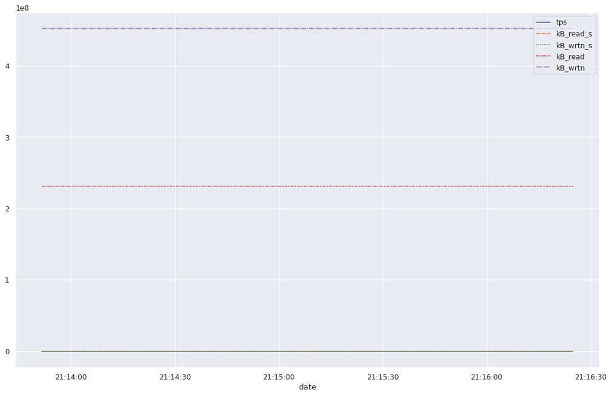

```python
plt.figure(figsize=(16,10), dpi= 80)
sns.set(style='darkgrid')
sns.lineplot(data=dsk_df)
```

Графики выглядят нормально. Возможно что-либо было выгружено из памяти или был завершен какой-то тяжелый процесс. Вообще запускать генератор нагрузки и тестируемую программу на одной машине неправильно. Тест прошол очень стабильно, однако в середине теста выросла задержка(Latency), что можно объяснить большим количеством тредов использующих сеть. Тестирование софта - увлекательный процесс. То, что сделано в данной работе - лишь моё мнение, и Я использовал для создания стенда максимально доступные инструменты - Jupiter Notebook с пакетами pandas, numpy, pyplot(matplotlib), seaborn, sklearn. Зонды были поставлены на основные компоненты: CPU, network, RAM, HDD, однако Я ограничился лишь отсутствием времени и небольшим опытом использования специализированных утилит. Среди которых можно выделить Micro Focus Dynamic с неинвазивным мониторингом ПО, написанном на .NET, Python, Java и многих других языках. APM от Elastic с неинвазивным мониторингом ПО, написанном на Java, Go, Node.js, Python, Ruby, .NET (с которым Я кстати имел дело). Вместе с этим имеется Splunk, но он недоступен на российском рынке.

В качестве генератора нагрузки был использован ставший стандартом де-факто Apache Jmeter, однако существует еще много разлиного ПО для этого (например Yandex.Tank с генераторами Phantom, Jmeter, BFG, Pandora). Если объектом теста является http сервер, то на первых парах можно использовать Soap UI